# Summary statistics, vep data

## Model parameter means

Mean (SD) values are shown.

### Calibration parameters

intercept:

- Control: 0.12 (0.08)
- Amblyopia: 0.17 (0.1)
  - Amblyopia vs. controls: t(16.8) = 1.13, p = 0.27; Glass’s ∆ = 0.58
- Strabismus with equal acuity: 0.63 (0.26)

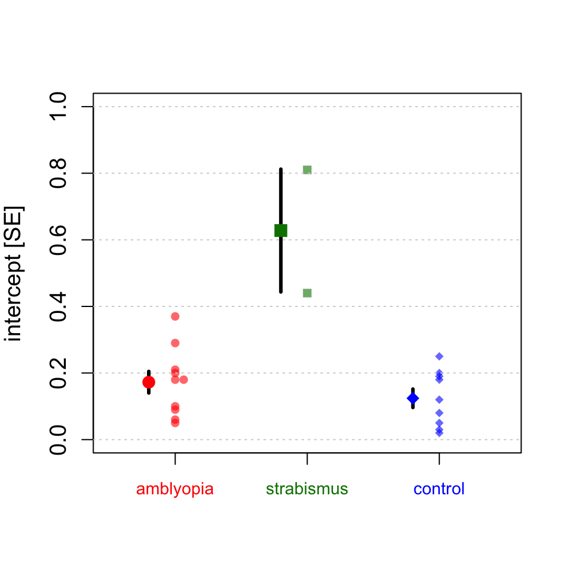

slope:

- Control: 1.92 (0.54)
- Amblyopia: 1.83 (0.39)
  - Amblyopia vs. controls: t(14.3) = 0.37, p = 0.71; Glass’s ∆ = 0.15
- Strabismus with equal acuity: 6.67 (5.07)

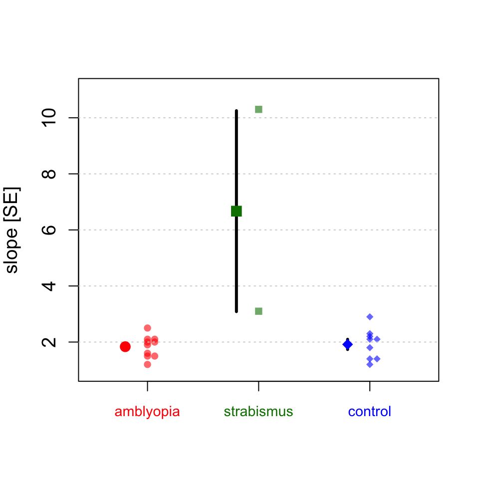

fit error (mean trials):

- Control: 0.01 (0.005)
- Amblyopia: 0.014 (0.006)
  - Amblyopia vs. controls: t(16.7) = 1.44, p = 0.17; Glass’s ∆ = 0.76
- Strabismus with equal acuity: 0.06 (0.046)

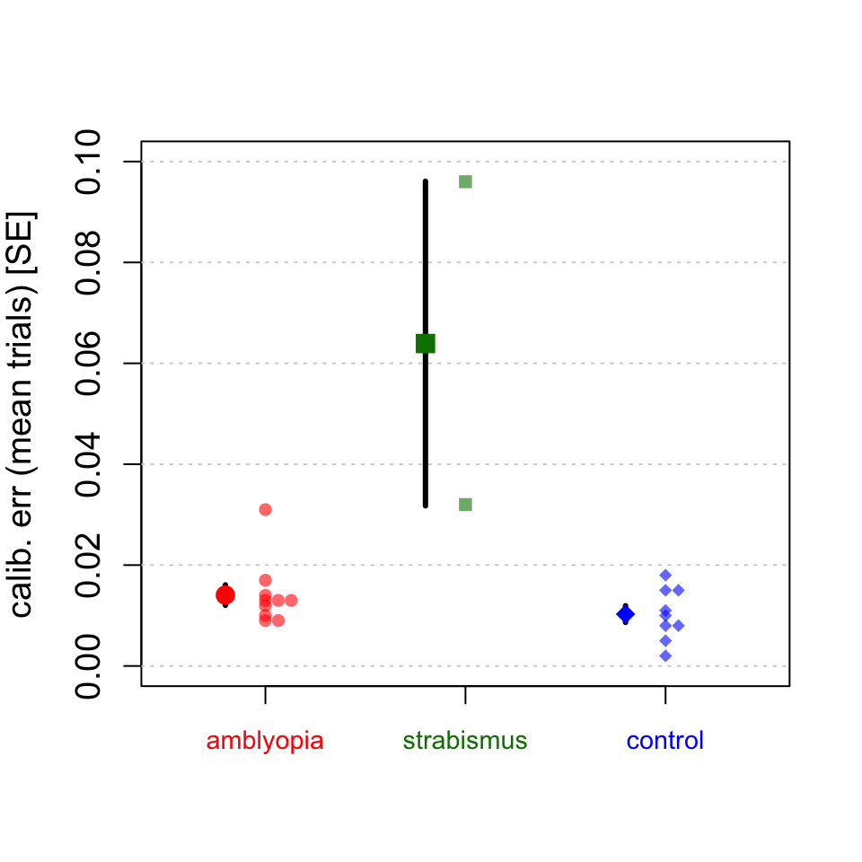

fit error (individual trials):

- Control: 0.003 (0.002)
- Amblyopia: 0.002 (0.002)
  - Amblyopia vs. controls: t(16.2) = 0.6, p = 0.56; Glass’s ∆ = 0.26
- Strabismus with equal acuity: 0.06 (0.071)

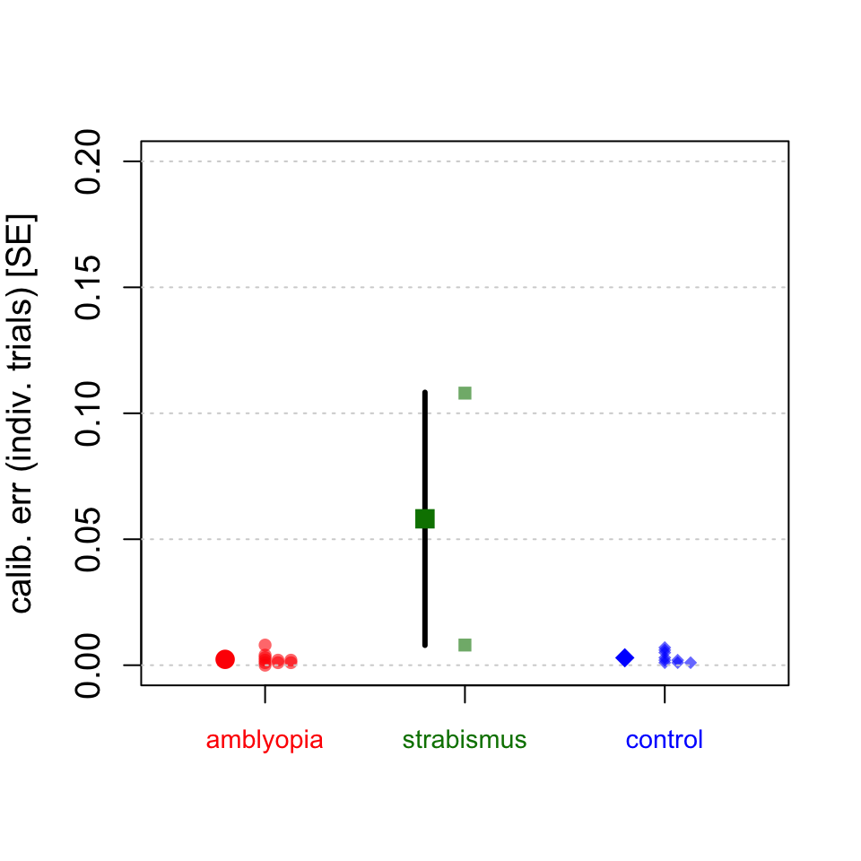

### Model parameters

k<sub>AE</sub>:

- Control: 0.88 (0.11)
- Amblyopia: 0.44 (0.47)
  - Amblyopia vs. controls: t(10.1) = 2.88, p = 0.016; Glass’s ∆ = 4.07
- Strabismus with equal acuity: 0.36 (0.5)

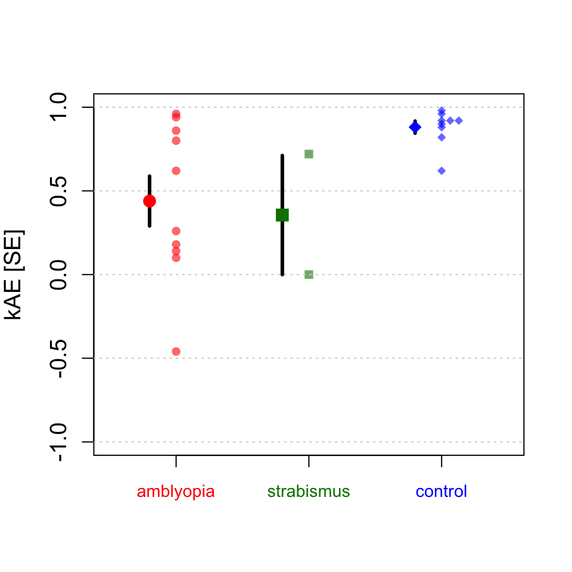

$\mu$<sub>AE</sub>:

- Control: 5.16 (7.07)
- Amblyopia: 4.4 (8.48)
  - Amblyopia vs. controls: t(16.9) = 0.21, p = 0.83; Glass’s ∆ = 0.11
- Strabismus with equal acuity: 0.3 (0.25)

$\mu$<sub>FE</sub>:

- Control: 1.68 (2.46)
- Amblyopia: 1.69 (3.05)
  - Amblyopia vs. controls: t(16.8) = 0.01, p = 0.99; Glass’s ∆ = 0
- Strabismus with equal acuity: 0.83 (1.17)

$\mu$ ANOVA test: No main effect of group, F(1,17) = 0.05, p = 0.83, genEtaSq = 0.001; no main effect of eye, F(1,17) = 2.2, p = 0.16, genEtaSq = 0.071; no group by eye interaction, F(1,17) = 0.03, p = 0.86, genEtaSq = 0.001. Simple main effects: no difference in uAE, F(1,17) = 0.04, p = 0.84, genEtaSq = 0.003; no difference in uFE, F(1,17) = 0, p = 0.99, genEtaSq = 3.8e-06.

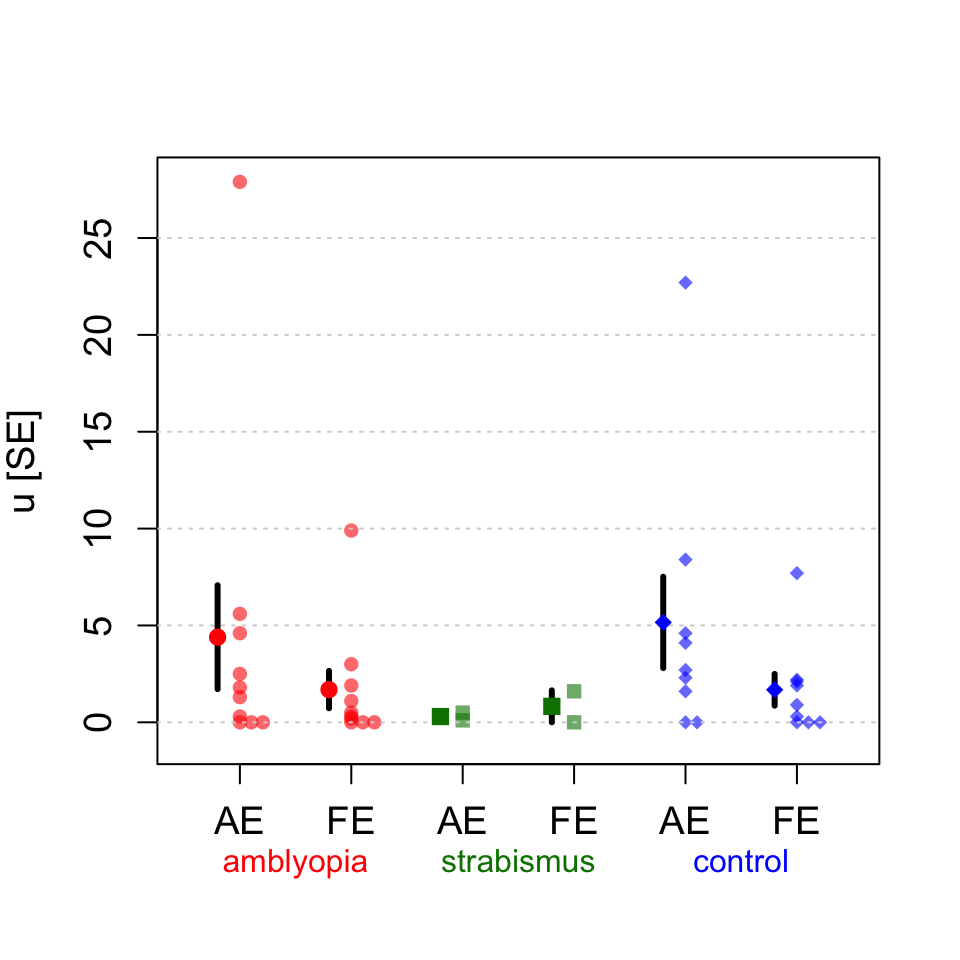

MSE:

- Control: 0.197 (0.121)
- Amblyopia: 0.146 (0.085)
  - Amblyopia vs. controls: t(14.3) = 1.06, p = 0.31; Glass’s ∆ = 0.42
- Strabismus with equal acuity: 2.81 (3.443)

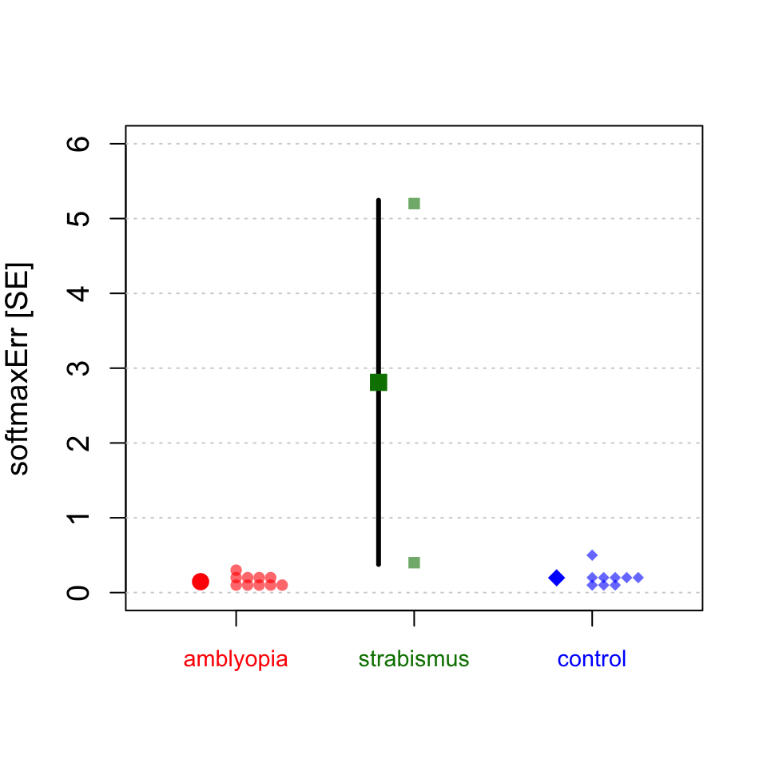